# Simulating breeding programs (Cattle 🐄)

Hector Marina

## Introduction

This practical focuses on the simulation of a dairy cattle breeding program using `AlphaSimR`. We will first generate a founder population and then define multiple quantitative traits with favorable and unfavorable genetic relationships. These traits will be incorporated into a simplified dairy cattle breeding program that includes systematic effects, selection, mating, and reproduction across generations. Finally, we will evaluate the response to selection and visualize changes in genetic merit over time.

1. Founder population
2. Systematic effects and phenotypic records
3. Dairy cattle breeding program
4. Selection across generations
5. Genetic and phenotypic response to selection

### Required packages

```r
library(AlphaSimR)
```

Let’s also set a random seed to make the simulation reproducible. Using the same seed will generate the same sequence of random events, whereas changing or removing the seed can produce slightly different outcomes from the simulation.

```r
set.seed(123)
```

## Founder population

We first generate a founder population representing a dairy cattle population. `AlphaSimR` uses the MaCS coalescent simulator to generate chromosome haplotypes while accounting for historical mutation, recombination, and changes in effective population size.

For cattle, `AlphaSimR` provides a predefined `"CATTLE"` demographic history based on cattle sequence data. We could simulate the 29 bovine autosomes and retain 6,000 segregating sites per chromosome, following parameters similar to those used in previous dairy cattle breeding simulations.

```r
founders=runMacs(
  nInd=1000,        # Founder individuals
  nChr=10,          # Simplified genome; cattle have 29 autosomes
  segSites=3000     # Segregating sites per chromosome (recommended 6000)
  #species="CATTLE"
)
```

> **NOTE:** To reduce computational time during the practical, we simulate 10 chromosomes rather than the complete 29 bovine autosomes and use the generic demographic history implemented in `AlphaSimR`. The objective is to reproduce the genetic processes underlying the breeding program rather than to recreate the complete Holstein genome.

### Define the simulation parameters

The `SimParam` object stores the genetic architecture, traits, marker information, environmental variance, and other parameters that will be used throughout the breeding program.

```r
SP=SimParam$new(founders)  # Create the simulation-parameter object from the founder genomes
SP$setSexes("yes_sys")     # Systematically assign males and females to individuals
SP$setTrackPed(TRUE)       # Store pedigree information across generations
```

### Define the traits

We simulate three traits:

1. **MY305**: 305-day milk yield in kg.
2. **LSCS**: lactation average somatic cell score.
3. **MAST**: underlying genetic propensity for clinical mastitis.

Parameters for MY305, LSCS, and clinical mastitis were based on first-lactation Swedish Holstein estimates reported by Carlén et al. (2004). Mean values were 7,575 kg for MY305 and 0.787 for LSCS, with additive genetic standard deviations of 712.2 kg and 0.1524 and heritabilities of 0.34 and 0.14, respectively. Clinical mastitis had a reported heritability of 0.03 and an incidence of 10.4%. For simulation, mastitis was represented on a standardized liability scale with mean 0 and phenotypic variance 1, giving an additive genetic variance of 0.03.

```r
trait_mean=c(
  7575,  # MY305, kg
  0.787, # LSCS
  0      # Mastitis liability
)

varA=c(
  712.2^2, # MY305
  0.1524^2,# LSCS
  0.03     # Mastitis liability
)

h2=c(
  0.34, # MY305
  0.14, # LSCS
  0.03  # Mastitis
)
```

The additive genetic correlations among the three traits are

$$\mathbf{R_A}=
\begin{pmatrix}
1 & 0.22 & 0.32\\
0.22 & 1 & 0.68\\
0.32 & 0.68 & 1
\end{pmatrix}$$

Thus, cows genetically predisposed to higher milk production also tend to have higher LSCS and greater mastitis susceptibility, while LSCS and mastitis are strongly positively correlated.

```r
corA=matrix(
  c(
    1.00, 0.22, 0.32,  # Correlations of MY305 with MY305, LSCS and mastitis
    0.22, 1.00, 0.68,  # Correlations of LSCS with MY305, LSCS and mastitis
    0.32, 0.68, 1.00   # Correlations of mastitis with MY305, LSCS and mastitis
  ),
  nrow=3,               # Number of traits
  byrow=TRUE             # Fill the matrix by rows
)

colnames(corA)=c("MY305","LSCS","MAST") # Add trait names to columns
rownames(corA)=c("MY305","LSCS","MAST") # Add trait names to rows
```

The corresponding additive genetic covariance matrix can be calculated as

$$\mathbf{G}
=
\mathbf{D_A}\mathbf{R_A}\mathbf{D_A},$$

where $\mathbf{D_A}$ contains the additive genetic standard deviations.

```r
sdA=sqrt(varA)

covA=diag(sdA)%*%corA%*%diag(sdA)

colnames(covA)=rownames(covA)=c("MY305","LSCS","MAST")
round(covA,3)
```

```
##            MY305   LSCS   MAST
## MY305 507228.840 23.879 39.474
## LSCS      23.879  0.023  0.018
## MAST      39.474  0.018  0.030
```

We now assign the three correlated additive traits to the founder genomes. `addTraitA()` uses the same QTL for the three traits, with correlated allelic effects according to `corA`.

```r
SP$addTraitA(
  nQtlPerChr=100,                 # Number of quantitative trait loci per chromosome
  mean=trait_mean,                # Trait means in the founder population
  var=varA,                       # Additive genetic variances of the three traits
  corA=corA,                      # Additive genetic correlations among traits
  name=c("MY305","LSCS","MAST")   # Names assigned to the three traits
)
```

### Define environmental variation

Calculate the residual variances so the traits have the heritabilities described by Carlén et al. (2004).

```r
SP$setVarE(h2=h2)
```

The heritabilities defined here refer to the founder population. The residual variance subsequently remains fixed, whereas the additive genetic variance may change across generations as a consequence of selection imposed by the breeding program. Therefore, realised heritability does not necessarily need to remain constant throughout the breeding programme.

### Create the base population

The founder haplotypes can now be converted into an `AlphaSimR` population containing genetic values and phenotypes for the three traits.

```r
pop=newPop(
  founders,          # Founder genomes generated with runMacs()
  simParam=SP        # Simulation parameters containing traits and genetic architecture
)

pop                   # Display a summary of the population
```

```
## An object of class "Pop"
## Ploidy: 2
## Individuals: 1000
## Chromosomes: 10
## Loci: 30000
## Traits: 3
```

### Explore genetic and phenotypic variation

The population now contains genetic values and phenotypes for the three simulated traits. Because environmental variance was defined using `setVarE()`, phenotypes are automatically generated when the population is created.

For an additive trait, the phenotype of an individual ($P_i$) can be represented as

$$P_i=G_i+E_i,$$

where $G_i$ is the genetic value and $E_i$ is the environmental deviation.

The environmental deviation can therefore be recovered as

$$E_i=P_i-G_i.$$

```r
G=gv(pop)    # Extract genetic values for all individuals and traits
P=pheno(pop) # Extract phenotypic values for all individuals and traits
E=P-G        # Calculate environmental deviations
```

### Genetic and environmental contributions to MY305

For each animal, the phenotype results from the combination of its genetic value and its environmental deviation. The following plot illustrates this decomposition for the first 20 animals.

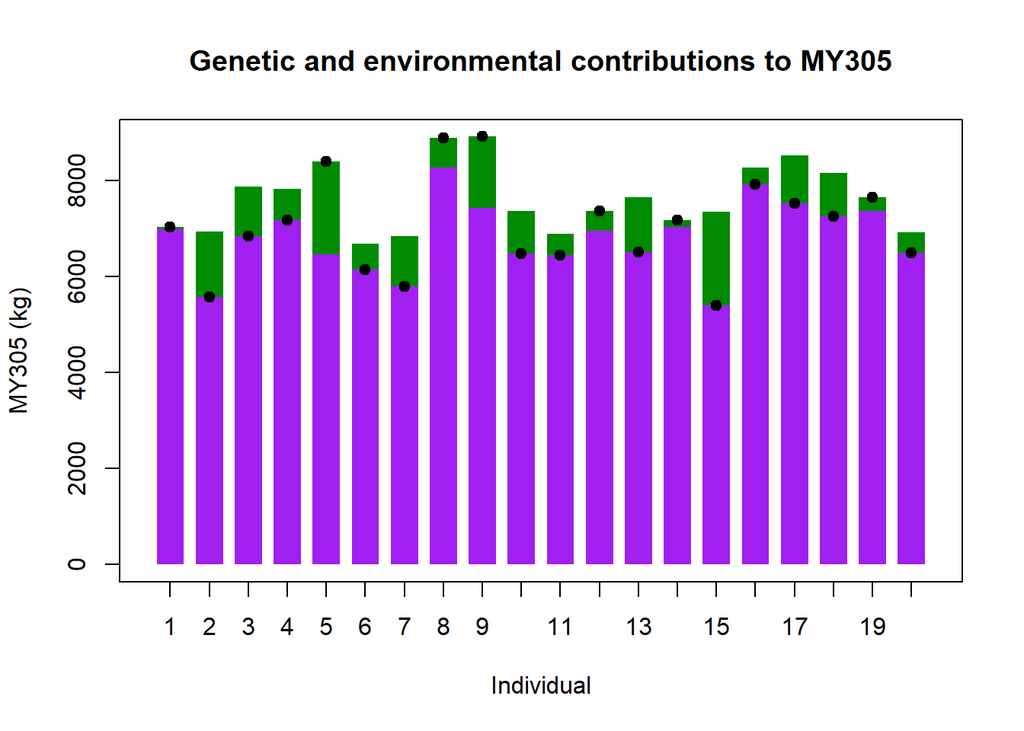

```r
# Trait 1 corresponds to MY305
my_G=G[,1]   # Genetic values
my_E=E[,1]   # Environmental deviations
my_P=P[,1]   # Phenotypes

# Select a subset of individuals for visualization
ids=1:20

# Create empty plot
plot(NA,
  xlim=c(0.5,length(ids)+0.5),
  ylim=range(c(0,my_G[ids],my_P[ids])),
  xlab="Individual", ylab="MY305 (kg)", xaxt="n",
  main="Genetic and environmental contributions to MY305"
)
axis(1,at=1:length(ids),labels=ids)


w=0.35 # Width of each bar
for(i in 1:length(ids)){
  id=ids[i]

  # Genetic component: from zero to genetic value
  rect(i-w,0,i+w,my_G[id],col="purple",border=NA)

  # Environmental component: from genetic value to phenotype
  rect(i-w,my_G[id], i+w,my_P[id], col="green4", border=NA)

  # Phenotypic value
  points(i,my_P[id],pch=19,col="black")
}
```

The purple section represents the genetic value of each animal. The green section represents the environmental deviation and connects the genetic value to the final phenotype (black dots). Environmental deviations can be either positive or negative; therefore, the phenotype can be higher or lower than the genetic value.

### Distribution of genetic values, environmental deviations and phenotypes

The three components can also be compared by visualizing their distributions.

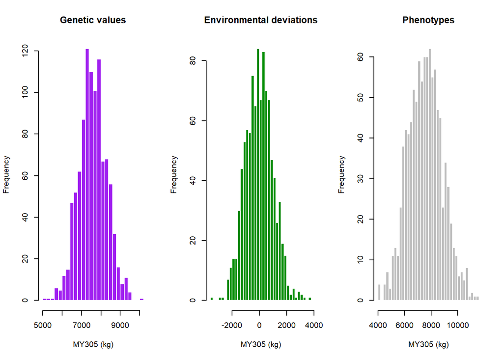

```r
par(mfrow=c(1,3))

hist(my_G,  breaks=30,  col="purple", border="white",
    main="Genetic values",          xlab="MY305 (kg)")

hist(my_E,  breaks=30,  col="green4",  border="white",
  main="Environmental deviations",  xlab="MY305 (kg)")

hist(my_P,  breaks=30,  col="grey",    border="white",
  main="Phenotypes",                xlab="MY305 (kg)")
```

```r
par(mfrow=c(1,1))
```

The genetic and environmental components combine to generate the broader distribution of phenotypic values.

### Check the genetic relationships among traits

The genetic values of the three traits can be used to verify that the simulated population approximately reproduces the genetic correlations specified when the traits were created.

```r
cor(G) # Genetic correlation matrix observed in the simulated population
```

```
##           MY305      LSCS      MAST
## MY305 1.0000000 0.2470095 0.3500202
## LSCS  0.2470095 1.0000000 0.6893491
## MAST  0.3500202 0.6893491 1.0000000
```

> **NOTE**: The realized correlations should be close to the target correlations, although they will not necessarily be identical because the simulation contains a finite number of individuals and QTL.

### Establish the farm structure

The founder females are divided among five dairy farms. With systematic sex assignment, 500 females are available, resulting in 100 cows per farm.

```r
n_farms=5              # Number of simulated dairy farms
cows=pop[pop@sex=="F"] # Extract all females from the founder population

# Randomly assign one farm ID to every cow
cows_to_farm=sample(rep(1:n_farms,length.out=cows@nInd))

# Create a list that will contain populations (One element per farm)
farms=vector(mode="list", length=n_farms)

for(farm in 1:n_farms)
  farms[[farm]]=cows[cows_to_farm==farm]
```

The number of cows on each farm can be checked using:

```r
sapply(farms,function(x) x@nInd)
```

```
## [1] 100 100 100 100 100
```

Sires are maintained separately in a common breeding population.

```r
sires=pop[pop@sex=="M"]  # Extract all sires (500) from the founder population
sires=list(sires)        # Store sires as a list so new male generations can be added later
```

### Generate the historical population

Before artificial selection begins, we simulate ten generations of random mating to establish a stable population structure with pedigree relationships and genetic relatedness among individuals. Across these generations, recombination, Mendelian sampling, and genetic drift progressively shape the population before directional selection is introduced.

In each generation, sires are drawn from a common male population and can be used across all farms. Female offspring remain on their farm of origin, whereas male offspring enter the common sire pool. Throughout this historical period, the population structure is kept approximately constant at 100 cows per farm and 500 males in the common sire population.

```r
n_gen_history=10   # Number of generations before artificial selection
n_cows_farm=100    # Number of cows maintained on each farm
n_sires=500        # Number of sires maintained in the common sire population
n_crosses=300      # Number of matings performed on each farm
n_progeny=1        # One offspring produced per mating

for(gen in 1:n_gen_history){   # Loop through historical generations

  sire_offspring=list()        # Store male offspring generated on each farm

  for(farm in 1:n_farms){      # Loop through farms

    offspring=randCross2(
      females=farms[[farm]],   # Females currently present on the farm
      males=mergePops(sires),  # Common sire population
      nCrosses=n_crosses,      # Number of matings on the farm
      nProgeny=n_progeny,      # One offspring per mating
      simParam=SP              # Simulation parameters
    )

    # Extract female offspring
    female_candidates=offspring[offspring@sex=="F"]

    # Randomly retain 100 females for the next generation
    farms[[farm]]=selectInd(
      female_candidates,
      nInd=n_cows_farm,        # Maintain 100 cows per farm
      sex="F",
      use="rand",              # No artificial selection yet
      simParam=SP
    )

    # Store male offspring generated on this farm
    sire_offspring[[farm]]=offspring[offspring@sex=="M"]
  }

  # Combine male offspring from all farms
  sire_candidates=mergePops(sire_offspring)

  # Randomly retain 500 sires for the next generation
  sires=list(
    selectInd(
      sire_candidates,
      nInd=n_sires,            # Maintain 500 sires
      sex="M",
      use="rand",              # No artificial selection yet
      simParam=SP
    )
  )
}
```

After these historical generations, `farms` contains the current female population on each farm and `sires` contains the pool of potential sires.

```r
farm_sizes=sapply(farms,function(x) x@nInd)   # Number of cows in each farm
n_sires=sires[[1]]@nInd                      # Number of sires in the common sire pool

cat(
  "After",n_gen_history,"historical generations, the population contains",
  sum(farm_sizes),"cows distributed across",n_farms,"farms (",
  paste(farm_sizes,collapse=", "),"cows per farm) and",
  n_sires,"sires in the common sire population.\n"
)
```

```
## After 10 historical generations, the population contains 500 cows distributed across 5 farms ( 100, 100, 100, 100, 100 cows per farm) and 500 sires in the common sire population.
```

No directional artificial selection has yet been applied. These populations form the starting point for the dairy cattle breeding program.

## Systematic effects and phenotypic records

So far, phenotypes have been generated as the combination of genetic and residual environmental variation. In a real dairy population, however, systematic environmental factors also influence the observed phenotype.

For this exercise, we will include two systematic effects:

- **Farm**, representing persistent differences in management and environment among farms.
- **Parity**, representing systematic changes in production and udder health as cows become older.

These effects modify the observed phenotype but do not alter the breeding value of the animal.

For an individual $i$ on farm $j$ and parity $k$, the observed phenotype is represented as

$$P_{ijk}=\mu+GV_i+F_j+L_k+E_i,$$

where $GV_i$ is the genetic value, $F_j$ is the farm effect, $L_k$ is the parity effect, and $E_i$ is the residual environmental deviation.

In `AlphaSimR`, the `fixEff` argument of `setPheno()` is intended for fixed-effect classes used by genomic-selection models rather than for numerically adding a farm or parity effect to the phenotype. We therefore add these systematic effects explicitly to the simulated phenotypic records.

### Generation interval

We assume a generation interval of 4.5 years (see [Stachowicz et al., 2011](https://doi.org/10.3168/jds.2010-3308)). Therefore, ten generations of selection correspond approximately to 45 years of breeding.

```r
generation_interval=4.5  # Approximate years between consecutive generations
n_gen_selection=10       # Number of generations under artificial selection

years=(0:n_gen_selection)*generation_interval  # Years represented by each generation
```

### Parity effects

Carlén et al. (2004) reported increasing milk yield, LSCS, and mastitis incidence across the first three lactations of Swedish Holstein cows. Mean MY305 increased from 7,575 kg in parity 1 to 8,832 and 9,308 kg in parities 2 and 3. LSCS increased from 0.787 to 0.891 and 0.995, while mastitis incidence increased from 10.4% to 12.1% and 14.9% (see Table 1).

We use parity 1 as the reference point, expressing the systematic effects of later parities as deviations from it. We also assume that parity 4 is equivalent to parity 3.

```r
# Observed mean MY305 for parities 1, 2, and 3=4
parity_MY=c(7575,8832,9308,9308)

# Observed mean LSCS for parities 1, 2, and 3=4
parity_LSCS=c(0.787,0.891,0.995,0.995)

# Observed mastitis prevalence for parities 1, 2, and 3=4
parity_MAST=c(0.104,0.121,0.149,0.149)
```

Milk and LSCS effects can be obtained directly as differences from parity 1.

```r
effect_MY=parity_MY-parity_MY[1]        # MY305 parity effects relative to parity 1
effect_LSCS=parity_LSCS-parity_LSCS[1]  # LSCS parity effects relative to parity 1
```

Because mastitis is simulated on an underlying liability scale, the observed prevalence must first be converted to the corresponding liability scale.

```r
# Liability threshold giving 10.4% mastitis prevalence in parity 1
mastitis_threshold=qnorm(1-parity_MAST[1])

# Change in liability required to reproduce parity-specific prevalence
effect_MAST=mastitis_threshold-qnorm(1-parity_MAST)
```

The three parity effects can then be stored together:

```r
parity_effect=cbind(
  MY305=effect_MY,      # Effect on 305-day milk yield
  LSCS=effect_LSCS,     # Effect on lactation somatic cell score
  MAST=effect_MAST      # Effect on mastitis liability
)

rownames(parity_effect)=paste0("Parity_",1:4)

round(parity_effect,3)
```

```
##          MY305  LSCS  MAST
## Parity_1     0 0.000 0.000
## Parity_2  1257 0.104 0.089
## Parity_3  1733 0.208 0.218
## Parity_4  1733 0.208 0.218
```

Parity 1 therefore represents the baseline, whereas parities 2, 3 and 4 systematically increase all three traits.

### Farm effects

We also introduce persistent differences among the five farms. These effects are centered around zero so that they modify differences among farms without systematically increasing or decreasing the population mean.

The values used here are illustrative rather than estimates from a specific population.

```r
farm_effect=matrix(
  c(-300,  0.05,  0.10,   # Farm 1
     200, -0.03, -0.05,   # Farm 2
       0,  0.00,  0.00,   # Farm 3
     350,  0.02,  0.05,   # Farm 4
    -250, -0.04, -0.10),  # Farm 5
  nrow=n_farms, byrow=TRUE
)

colnames(farm_effect)=c("MY305","LSCS","MAST")
rownames(farm_effect)=paste0("Farm_",1:n_farms)

farm_effect
```

```
##        MY305  LSCS  MAST
## Farm_1  -300  0.05  0.10
## Farm_2   200 -0.03 -0.05
## Farm_3     0  0.00  0.00
## Farm_4   350  0.02  0.05
## Farm_5  -250 -0.04 -0.10
```

The average farm effect is zero for every trait:

```r
colMeans(farm_effect)
```

```
##        MY305         LSCS         MAST
## 0.000000e+00 6.938894e-19 0.000000e+00
```

### Generate observed phenotypic records

To simplify the simulation, we do not model the complete lifetime of individual cows. Instead, parity is treated as a systematic effect on each phenotypic record.

We assume that each farm contains cows distributed across four parities. The intended proportions are 25%, 25%, 25%, and 25% for parities 1 to 4, respectively. This distribution is kept constant so that changes across generations are driven primarily by genetic selection rather than by changes in herd age structure.

```r
extract_records=function(farms,generation){

  records=list()  # Store records generated for each farm

  for(farm in 1:n_farms){

    cow_pop=farms[[farm]]  # Current cows on the farm
    n=cow_pop@nInd         # Number of cows on the farm

    # Assign 25% of cows to each of the four parities
    parity=sample(rep(1:4,each=n/4))

    # Extract phenotypes generated by AlphaSimR
    P=pheno(cow_pop)

    # Extract genetic values
    GV=gv(cow_pop)

    # Add farm and parity effects to each phenotype
    for(i in 1:n)
      P[i,]=P[i,]+parity_effect[parity[i],]+farm_effect[farm,]

    # Convert mastitis liability to a binary mastitis phenotype
    mastitis=as.numeric(P[,3]>mastitis_threshold)

    # Store all information for the current farm
    records[[farm]]=data.frame(
      generation=generation,
      year=generation*generation_interval,
      farm=farm,
      id=cow_pop@id,
      parity=parity,
      GV_MY305=GV[,1],
      GV_LSCS=GV[,2],
      GV_MAST=GV[,3],
      MY305=P[,1],
      LSCS=P[,2],
      MAST_liability=P[,3],
      MAST=mastitis
    )
  }

  # Combine records from all farms
  do.call(rbind,records)
}
```

The function can be applied to the population before artificial selection begins:

```r
records0=extract_records(farms=farms,generation=0)
head(records0)
```

```
##   generation year farm    id parity GV_MY305   GV_LSCS     GV_MAST    MY305
## 1          0    0    1 14520      1 7467.152 0.5207702 -0.15141269 5963.993
## 2          0    0    1 14750      2 7539.052 0.9916344  0.15737708 7881.984
## 3          0    0    1 14526      3 8038.528 0.8978187  0.03830576 8304.927
## 4          0    0    1 14776      3 7708.967 0.8078696  0.08381290 9963.836
## 5          0    0    1 14590      3 7261.302 0.8358948 -0.10399051 7659.647
## 6          0    0    1 14770      4 6651.884 0.6666619 -0.04637254 9786.341
##        LSCS MAST_liability MAST
## 1 1.3914572     -0.3017911    0
## 2 0.8447511      0.7380166    0
## 3 1.4334648      0.2584228    0
## 4 1.0759378      1.7890510    1
## 5 1.0710292      0.6208978    0
## 6 0.7678243      1.3417227    1
```

The resulting data contain the genetic values and observed phenotypes of every cow, together with its farm and parity.

## Dairy cattle breeding program

We will now apply artificial selection for higher 305-day milk yield.

Selection will be based on the *true genetic value for MY305*. This represents an idealized breeding program in which the genetic merit of every selection candidate is known perfectly.

Because all traits were simulated as additive traits, `AlphaSimR` allows genetic values to be used directly as the selection criterion using `use="gv"`.

We assume that, in each generation:

- the best 50 sires are selected from the common population of 500 males;
- the best 50 cows are selected as dams within each farm;
- selection is based only on MY305;
- selected parents produce the candidates for the next generation;
- 100 female replacements are retained per farm;
- 500 males are retained in the common sire population.

```r
n_selected_sires=50   # Number of breeding sires selected from 500 candidates
n_selected_dams =50   # Number of breeding cows selected within each farm

selection_trait=1     # Trait 1 corresponds to MY305
```

> **NOTE:** Selection is deliberately based on only one trait. Because MY305 is positively genetically correlated with LSCS and mastitis, selection for increased milk production is expected to produce correlated genetic responses in both udder-health traits.

## Selection across generations

Before starting selection, we create objects to store genetic and phenotypic changes across generations.

```r
# Store mean genetic values across generations
GV_progress=matrix(NA,nrow=n_gen_selection+1,ncol=3)

colnames(GV_progress)=c("MY305","LSCS","MAST")
rownames(GV_progress)=0:n_gen_selection

# Store mean observed phenotypes
P_progress=matrix(NA, nrow=n_gen_selection+1, ncol=3)

colnames(P_progress)=c("MY305","LSCS","MAST")
rownames(P_progress)=0:n_gen_selection

# Store individual phenotypic records for every generation
records_history=vector(mode="list", length=n_gen_selection+1)
```

### Record the population before selection

Generation 0 corresponds to the population obtained after the historical generations.

```r
# Combine cows from all farms
all_cows=mergePops(farms)

# Mean genetic values before selection
GV_progress[1,]=colMeans(gv(all_cows))

# Generate phenotypic records
records_history[[1]]=extract_records(farms=farms, generation=0)

# Store population-average phenotypes
P_progress[1,1]=mean(records_history[[1]]$MY305)
P_progress[1,2]=mean(records_history[[1]]$LSCS)
P_progress[1,3]=mean(records_history[[1]]$MAST)*100
```

### Run the breeding program

We now repeat selection and reproduction for ten generations.

```r
for(gen in 1:n_gen_selection){

  # Select the 50 sires with the highest genetic value for MY305
  selected_sires=selectInd(
    mergePops(sires),
    nInd=n_selected_sires,
    sex="M",
    trait=selection_trait,
    use="gv",
    selectTop=TRUE,
    simParam=SP
  )

  # List for male offspring produced across farms
  sire_offspring=list()

  for(farm in 1:n_farms){

    # Select the 50 cows with the highest MY305 genetic values on this farm
    selected_dams=selectInd(
      farms[[farm]],
      nInd=n_selected_dams,
      sex="F",
      trait=selection_trait,
      use="gv",
      selectTop=TRUE,
      simParam=SP
    )

    # Mate selected dams with selected sires
    offspring=randCross2(
      females=selected_dams,
      males=selected_sires,
      nCrosses=n_crosses,
      nProgeny=n_progeny,
      simParam=SP
    )

    # Extract female replacement candidates
    female_candidates=offspring[offspring@sex=="F"]

    # Randomly retain 100 females for the next generation on this farm
    farms[[farm]]=selectInd(
      female_candidates,
      nInd=n_cows_farm,
      sex="F",
      use="rand",
      simParam=SP
    )

    # Store male offspring generated on this farm
    sire_offspring[[farm]]=offspring[offspring@sex=="M"]
  }

  # Combine male offspring from all farms
  sire_candidates=mergePops(sire_offspring)

  # Randomly retain 500 males as the sire population for the next generation
  sires=list(
    selectInd(
      sire_candidates,
      nInd=n_sires,
      sex="M",
      use="rand",
      simParam=SP
    )
  )

  # Combine cows from all farms in the new generation
  all_cows=mergePops(farms)

  # Store average genetic values of the new generation
  GV_progress[gen+1,]=colMeans(gv(all_cows))

  # Generate phenotypic records including parity and farm effects
  records_history[[gen+1]]=extract_records(farms=farms,generation=gen)

  # Store mean MY305, LSCS and mastitis prevalence (%)
  P_progress[gen+1,1]=mean(records_history[[gen+1]]$MY305)
  P_progress[gen+1,2]=mean(records_history[[gen+1]]$LSCS)
  P_progress[gen+1,3]=mean(records_history[[gen+1]]$MAST)*100

  # Print progress while the simulation is running
  cat(
    "Generation",gen,
    "- Year",gen*generation_interval,
    "- Mean MY305 GV:",round(GV_progress[gen+1,1],1),
    "\n"
  )
}
```

```
## Generation 1 - Year 4.5 - Mean MY305 GV: 8355.5
## Generation 2 - Year 9 - Mean MY305 GV: 9092.4
## Generation 3 - Year 13.5 - Mean MY305 GV: 9851.9
## Generation 4 - Year 18 - Mean MY305 GV: 10458.6
## Generation 5 - Year 22.5 - Mean MY305 GV: 11197.3
## Generation 6 - Year 27 - Mean MY305 GV: 11850
## Generation 7 - Year 31.5 - Mean MY305 GV: 12514.8
## Generation 8 - Year 36 - Mean MY305 GV: 13149
## Generation 9 - Year 40.5 - Mean MY305 GV: 13760.4
## Generation 10 - Year 45 - Mean MY305 GV: 14459.4
```

The breeding program has now simulated ten generations, corresponding approximately to 45 years under the assumed generation interval.

## Genetic and phenotypic response to selection

We can first inspect changes in the average genetic values.

```r
GV_progress
```

```
##        MY305      LSCS        MAST
## 0   7563.174 0.7863860 0.002406339
## 1   8355.451 0.8301352 0.074480139
## 2   9092.418 0.8629338 0.140302689
## 3   9851.893 0.9011297 0.191326208
## 4  10458.615 0.9059303 0.204041845
## 5  11197.270 0.9521366 0.276054737
## 6  11850.023 0.9636999 0.304138889
## 7  12514.805 1.0142035 0.364285627
## 8  13148.958 1.0547314 0.412582728
## 9  13760.388 1.0749146 0.446498308
## 10 14459.449 1.1146127 0.493854464
```

### Genetic response

Selection was applied only to MY305. However, because the three traits are genetically correlated, changes are also expected in LSCS and mastitis liability.

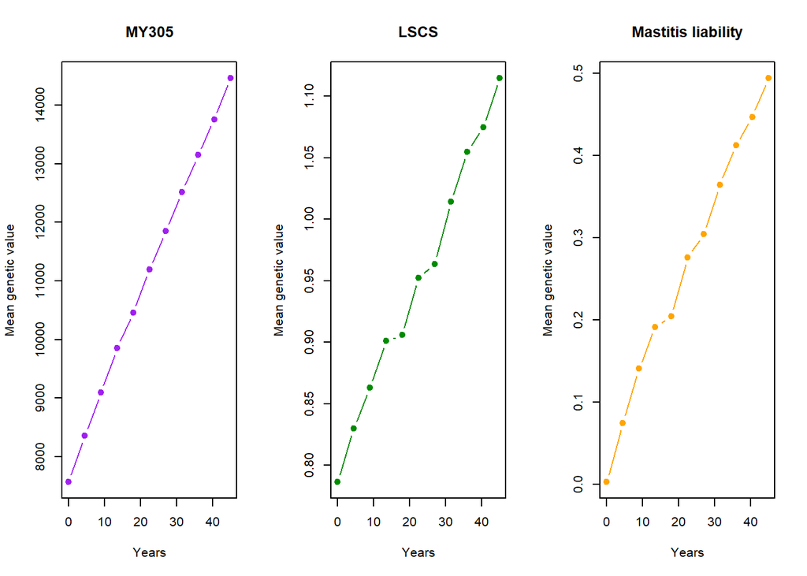

```r
par(mfrow=c(1,3))
plot(years,GV_progress[,1], type="b",pch=19, col="purple",
  xlab="Years", ylab="Mean genetic value", main="MY305")
plot(years,GV_progress[,2], type="b",pch=19, col="green4",
  xlab="Years", ylab="Mean genetic value", main="LSCS")
plot(years,GV_progress[,3], type="b",pch=19, col="orange",
  xlab="Years", ylab="Mean genetic value", main="Mastitis liability")
```

```r
par(mfrow=c(1,1))
```

### Phenotypic response

The observed phenotypes include the genetic response, residual environmental variation, parity effects, and persistent farm effects.

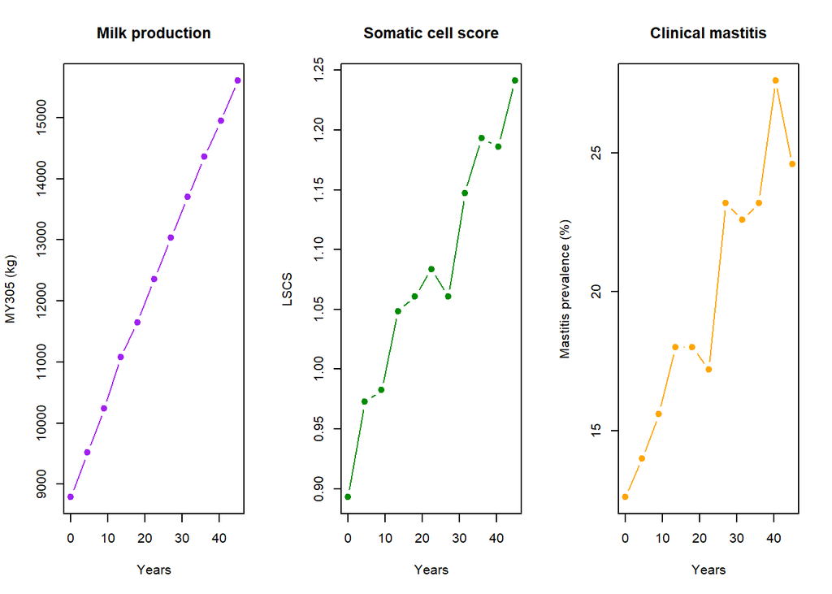

```r
par(mfrow=c(1,3))
plot(years,P_progress[,1], type="b",pch=19,  col="purple",
  xlab="Years", ylab="MY305 (kg)", main="Milk production")
plot(years,P_progress[,2], type="b",pch=19,  col="green4",
  xlab="Years", ylab="LSCS",       main="Somatic cell score")
plot(years,P_progress[,3], type="b",pch=19,  col="orange",
  xlab="Years", ylab="Mastitis prevalence (%)",  main="Clinical mastitis")
```

```r
par(mfrow=c(1,1))
```

Selection should produce a clear increase in MY305. Because MY305 has unfavorable positive genetic correlations with LSCS and mastitis, increases in these traits may occur as correlated responses even though they were not included directly in the selection criterion.

### Compare the first and last generations

The total genetic change after ten generations can be summarized as:

```r
genetic_change=GV_progress[n_gen_selection+1,]-GV_progress[1,]

cat(
  "Genetic change after",n_gen_selection,"generations:\n",
  "MY305:",round(genetic_change["MY305"],1),"kg\n",
  "LSCS:",round(genetic_change["LSCS"],3),"\n",
  "Mastitis liability:",round(genetic_change["MAST"],3),"\n"
)
```

```
## Genetic change after 10 generations:
##  MY305: 6896.3 kg
##  LSCS: 0.328
##  Mastitis liability: 0.491
```

The corresponding phenotypic change can be calculated as:

```r
phenotypic_change=P_progress[n_gen_selection+1,]-P_progress[1,]

cat(
  "Phenotypic change after",n_gen_selection,"generations:\n",
  "MY305:",round(phenotypic_change["MY305"],1),"kg\n",
  "LSCS:",round(phenotypic_change["LSCS"],3),"\n",
  "Mastitis prevalence:",
  round(phenotypic_change["MAST"],2),
  "percentage points\n"
)
```

```
## Phenotypic change after 10 generations:
##  MY305: 6815.5 kg
##  LSCS: 0.348
##  Mastitis prevalence: 12 percentage points
```

Because the simulated phenotypic records contain information on farm, parity, and generation, we can use a linear model to test whether the systematic effects introduced into the simulation can be recovered.

First, we combine the records from all generations into a single data frame.

```r
# Combine individual records from all generations
records_all=do.call(rbind,records_history)

# Treat farm, parity and generation as categorical effects
records_all$farm=factor(records_all$farm)
records_all$parity=factor(records_all$parity)
records_all$generation=factor(records_all$generation)

# Use parity 1 and generation 0 as reference levels
records_all$farm=relevel(records_all$farm,ref="3")
records_all$parity=relevel(records_all$parity,ref="1")
records_all$generation=relevel(records_all$generation,ref="0")
```

Let’s fit MY305 using the systematic effects:

$$P_{ijkl}=F_j+L_k+G_l+e_{ijkl},$$
where $F_j$ is the farm effect, $L_k$ is the parity effect, and $G_l$ is the generation effect.

```r
model_MY=lm(MY305 ~ farm + parity + generation, data=records_all)
summary(model_MY)
```

```
##
## Call:
## lm(formula = MY305 ~ farm + parity + generation, data = records_all)
##
## Residuals:
##     Min      1Q  Median      3Q     Max
## -4564.0  -765.4     7.3   775.3  4429.6
##
## Coefficients:
##              Estimate Std. Error t value Pr(>|t|)
## (Intercept)   7651.02      64.64 118.356  < 2e-16 ***
## farm1         -330.00      48.18  -6.849 8.26e-12 ***
## farm2          107.39      48.18   2.229   0.0259 *
## farm4          312.26      48.18   6.481 9.93e-11 ***
## farm5         -290.92      48.18  -6.038 1.66e-09 ***
## parity2       1253.32      43.10  29.082  < 2e-16 ***
## parity3       1784.40      43.10  41.405  < 2e-16 ***
## parity4       1671.40      43.10  38.783  < 2e-16 ***
## generation1    734.82      71.47  10.282  < 2e-16 ***
## generation2   1448.91      71.47  20.274  < 2e-16 ***
## generation3   2292.37      71.47  32.076  < 2e-16 ***
## generation4   2864.03      71.47  40.075  < 2e-16 ***
## generation5   3568.54      71.47  49.933  < 2e-16 ***
## generation6   4244.87      71.47  59.397  < 2e-16 ***
## generation7   4912.60      71.47  68.740  < 2e-16 ***
## generation8   5568.49      71.47  77.917  < 2e-16 ***
## generation9   6158.24      71.47  86.170  < 2e-16 ***
## generation10  6815.53      71.47  95.367  < 2e-16 ***
## ---
## Signif. codes:  0 '***' 0.001 '**' 0.01 '*' 0.05 '.' 0.1 ' ' 1
##
## Residual standard error: 1130 on 5482 degrees of freedom
## Multiple R-squared:  0.8029, Adjusted R-squared:  0.8023
## F-statistic:  1313 on 17 and 5482 DF,  p-value: < 2.2e-16
```

The same approach can be applied to LSCS and mastitis liability.

### Exercise: Exploring alternative breeding strategies

1. *Selection for different traits.*  
   The current breeding program selects animals only for higher MY305. Repeat the simulation selecting instead for lower LSCS or lower mastitis liability.

   How does direct selection on each trait affect the genetic and phenotypic response of the other two traits?
2. *Selection intensity.*  
   Modify the number of selected sires and dams used in each generation. For example, compare a scenario using only a small proportion of the available sires with a scenario using a larger number of sires.

   How does stronger selection affect genetic progress? What would happen to the genetic variability remaining in the population?

   Compare different combinations of selection pressure in males and females. Is increasing selection intensity equally effective in both pathways?
3. *Multi-trait selection index.*  
   In practice, dairy cattle are rarely selected for a single trait. Construct a simple selection index that rewards higher milk production while penalizing higher LSCS.

   For this exercise, assume a milk value of approximately **4.66 SEK per kg of milk**, based on a recent Swedish conventional milk price. For teaching purposes, also assume a simplified linear penalty of **0.20 SEK per kg of milk for every 0.1-unit increase in LSCS**.

   Using the baseline production of 7,575 kg, the approximate penalty per one LSCS unit is therefore

   $$\frac{0.20\times7575}{0.1}=15150\ \text{SEK}.$$

   A simplified economic selection index can therefore be written as

   $$I=4.66\,GV_{\mathrm{MY305}}
   -15150\,GV_{\mathrm{LSCS}}.$$

   > **NOTE:** This is a deliberately simplified linear economic index for teaching purposes. Real milk-payment systems depend on several milk-quality components and do not apply a constant linear penalty to LSCS.

   `AlphaSimR` allows a function to be supplied to the `trait` argument of `selectInd()`. The function `selIndex()` can therefore be used to combine several traits.

   For example, define the economic weights as:

   ```r
     selected_dams=selectInd(
    farms[[farm]],
    nInd=n_selected_dams,
    sex="F",
    trait=selIndex,                 # It combines several traits in a selection index
    use="gv",                       # Use genetic values
    b=c(4.66,-15150,0),             # MY305, LSCS and mastitis weights
    selectTop=TRUE,
    simParam=SP
     )
   ```

## Recommended literature

- Gaynor, R.C., Gorjanc, G. & Hickey, J.M. (2021). [AlphaSimR: an R package for breeding program simulations](https://doi.org/10.1093/g3journal/jkaa017). *G3 Genes|Genomes|Genetics*.
- Carlén, E., Strandberg, E. & Roth, A. (2004). Genetic parameters for clinical mastitis, somatic cell score, and production in the first three lactations of Swedish Holstein cows. *Journal of Dairy Science*.
- Stachowicz, K., Sargolzaei, M., Miglior, F., Schenkel, F.S. 2011. [Rates of inbreeding and genetic diversity in Canadian Holstein and Jersey cattle](https://doi.org/10.3168/jds.2010-3308). *Journal of Dairy Science.*
- Lillehammer, M., Meuwissen, T.H.E. & Sonesson, A.K. (2011). [A comparison of dairy cattle breeding designs that use genomic selection](https://doi.org/10.3168/jds.2010-3518). *Journal of Dairy Science*.
- Medrano, J.F., Ahmadi, A. & Casellas, J. (2010). [Dairy Cattle Breeding Simulation Program: A simulation program to teach animal breeding principles and practices](https://doi.org/10.3168/jds.2009-2640). *Journal of Dairy Science*.
- Strandén, I., Kantanen, J., Russo, I.-R.M., Orozco-terWengel, P., Bruford, M.W. & Climgen Consortium (2019). [Genomic selection strategies for breeding adaptation and production in dairy cattle under climate change](https://doi.org/10.1038/s41437-019-0207-1). *Heredity*.
- Hansson, I., Bijma, P., Fikse, F. & Rönnegård, L. (2025). [Towards assessing indirect genetic effects in dairy cattle](https://doi.org/10.1186/s12711-025-00988-w). *Genetics Selection Evolution*.
- Bengtsson, C., Stålhammar, H., Thomasen, J.R., Fikse, W.F., Strandberg, E., Eriksson, S. & Johnsson, M. (2025). [Simulation of long-term impact of dairy cattle mating programmes using genomic information at the herd level](https://doi.org/10.1016/j.animal.2025.101498). *Animal*.